# Hunters Green House Price prediction

## Data cleaning & Transformations

Made changes to 4 garages column values by getting values from Zillow

Making a copy of the original dataset

```r
df_new <- df
```

Renamed adom and cdom columns

```r
df_new <- rename(df_new, adom = adom_agentdaysonmarket)
df_new <- rename(df_new, cdom = cdom_cumuldaysmls)
```

Some of houses have been relisted and sold again between 2015 and 2020.

```r
df_new %>%
  count(Address) %>%
  filter(., n>1)
```

```
## # A tibble: 29 x 2
##    Address                    n
##    <chr>                  <int>
##  1 17515 EDINBURGH DR         2
##  2 17517 EDINBURGH DR         2
##  3 17624 NATHANS DR           2
##  4 17706 EMERALD GREEN PL     2
##  5 17711 ESPRIT DR            2
##  6 17714 LONG RIDGE RD        2
##  7 17731 LONG RIDGE RD        2
##  8 17809 HICKORY MOSS PL      2
##  9 17815 HICKORY MOSS PL      2
## 10 17827 OSPREY POINTE PL     2
## # ... with 19 more rows
```

Taking only one record of those houses by filtering for latest selling date.

```r
df_new <- df_new %>%
  mutate(Date = as.Date(x = datesold, format = "%y/%m/%d")) %>%
  group_by(Address) %>%
  arrange(desc(Date)) %>%
  slice(1)
```

Checking for null values

```r
colSums((is.na(df_new)))
```

```
##     slnoskm      Status     Address        Beds   bathsfull   bathshalf
##           0           0           0           0           0           0
##  bathstotal        sqft     garages        Roof     lotsqft       yrblt
##           0           0           0           0           0           0
##        Pool         spa     subdivn        adom        cdom   listprice
##           0         296           0           0           0           0
##   lppersqft PendingDate   pricesold   sppersqft    datesold     splsale
##           0           0           0           0           0           0
##        Date
##           0
```

Replacing null values in Spa field with FALSE

```r
df_new <- df_new %>%
mutate(spa = replace_na(spa,FALSE))
```

### Data transformation

Halving the values of half baths and adding it to bathsfull

```r
df_new$bath <- (df_new$bathsfull + (df_new$bathshalf/2))
```

Finding how old a house was at the time the house was by finding the difference between year built and pending date.

```r
df_new$yrsold <- as.numeric(format(df_new$PendingDate, format = "%Y")) - df_new$yrblt
```

Changing values in roof field

```r
df_new <- df_new %>%
  mutate(Roof = case_when(
    Roof == "Slate, Tile" ~ "Tile",
    Roof == "Shingle, Tile" ~ "Tile",
    Roof == "Shake, Shingle" ~ "Shingle",
    Roof == "Slate" ~ "Tile",
    Roof == "Built-Up" ~ "Shingle",
    Roof == "Other" ~ "Tile",
    Roof == "Concrete, Tile" ~ "Tile",
    Roof == "Tile" ~ "Tile",
    Roof == "Shingle" ~ "Shingle"
  ))
```

Count & percentage of categories in Roof

```r
janitor::tabyl(df_new, Roof)
```

```
##     Roof   n   percent
##  Shingle 227 0.5022124
##     Tile 225 0.4977876
```

```r
janitor::tabyl(df_new, spa)
```

```
##    spa   n   percent
##  FALSE 324 0.7168142
##   TRUE 128 0.2831858
```

```r
janitor::tabyl(df_new, Pool)
```

```
##                Pool   n   percent
##           Community  56 0.1238938
##                None  80 0.1769912
##             Private 239 0.5287611
##  Private, Community  77 0.1703540
```

```r
janitor::tabyl(df_new, splsale)
```

```
##                  splsale   n     percent
##  Auction, Bank Owned/REO   1 0.002212389
##           Bank Owned/REO  18 0.039823009
##                     None 428 0.946902655
##               Short Sale   5 0.011061947
```

factorizing all categorical variables

```r
df_new$Roof <- factor(df_new$Roof)
df_new$Pool <- factor(df_new$Pool)
df_new$spa <- factor(df_new$spa)
df_new$splsale <- factor(df_new$splsale)
```

transferring cleaned and transformed dataframe to original one

```r
df <- df_new
remove(df_new)
```

removing columns which are not useful for predicting house prices

```r
df <- subset(x = df,select = -c(bathsfull,bathshalf,bathstotal,Address,Status,slnoskm,Date,datesold,sppersqft,subdivn))
```

### EDA

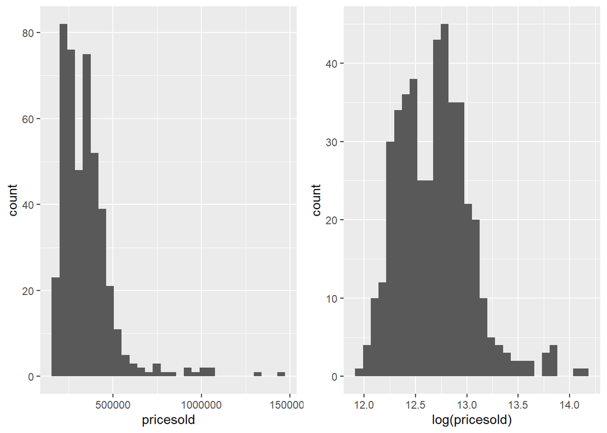

The histogram is clearly skewed to the right. However doing a log on price sold makes it look normally distributed. We may have to use a exponential model for the price sold.

Using the library performance analytics on numeric columns. This is to check for the relationship between all numeric variables.

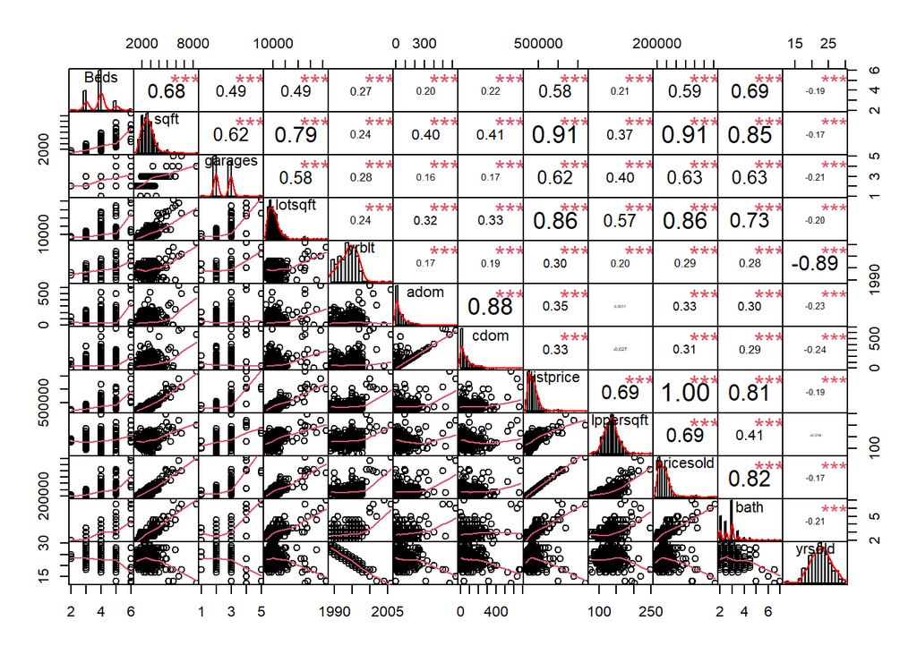

```r
summary(df)
```

```
##       Beds            sqft         garages           Roof        lotsqft
##  Min.   :2.000   Min.   :1305   Min.   :1.000   Shingle:227   Min.   : 4500
##  1st Qu.:3.000   1st Qu.:2074   1st Qu.:2.000   Tile   :225   1st Qu.: 7150
##  Median :4.000   Median :2531   Median :2.000                 Median : 9600
##  Mean   :3.863   Mean   :2634   Mean   :2.487                 Mean   :10861
##  3rd Qu.:4.000   3rd Qu.:3001   3rd Qu.:3.000                 3rd Qu.:12376
##  Max.   :6.000   Max.   :8398   Max.   :5.000                 Max.   :52438
##      yrblt                      Pool        spa           adom
##  Min.   :1989   Community         : 56   FALSE:324   Min.   :  0.00
##  1st Qu.:1992   None              : 80   TRUE :128   1st Qu.: 10.00
##  Median :1994   Private           :239               Median : 34.00
##  Mean   :1994   Private, Community: 77               Mean   : 61.43
##  3rd Qu.:1996                                        3rd Qu.: 78.00
##  Max.   :2006                                        Max.   :633.00
##       cdom          listprice         lppersqft
##  Min.   :  0.00   Min.   : 165000   Min.   : 74.92
##  1st Qu.: 11.00   1st Qu.: 250000   1st Qu.:118.79
##  Median : 39.00   Median : 330000   Median :132.98
##  Mean   : 71.63   Mean   : 357141   Mean   :133.11
##  3rd Qu.: 92.25   3rd Qu.: 400000   3rd Qu.:144.83
##  Max.   :674.00   Max.   :1695000   Max.   :248.29
##   PendingDate                    pricesold                          splsale
##  Min.   :2015-01-16 00:00:00   Min.   : 160000   Auction, Bank Owned/REO:  1
##  1st Qu.:2016-03-12 18:00:00   1st Qu.: 248375   Bank Owned/REO         : 18
##  Median :2017-06-15 00:00:00   Median : 328500   None                   :428
##  Mean   :2017-05-29 23:34:30   Mean   : 347210   Short Sale             :  5
##  3rd Qu.:2018-07-22 06:00:00   3rd Qu.: 399900
##  Max.   :2019-12-15 00:00:00   Max.   :1435000
##       bath           yrsold
##  Min.   :2.000   Min.   :12.00
##  1st Qu.:2.500   1st Qu.:21.00
##  Median :3.000   Median :23.00
##  Mean   :2.819   Mean   :22.81
##  3rd Qu.:3.000   3rd Qu.:25.00
##  Max.   :7.000   Max.   :30.00
```

Does having a swimming pool affect price sold?

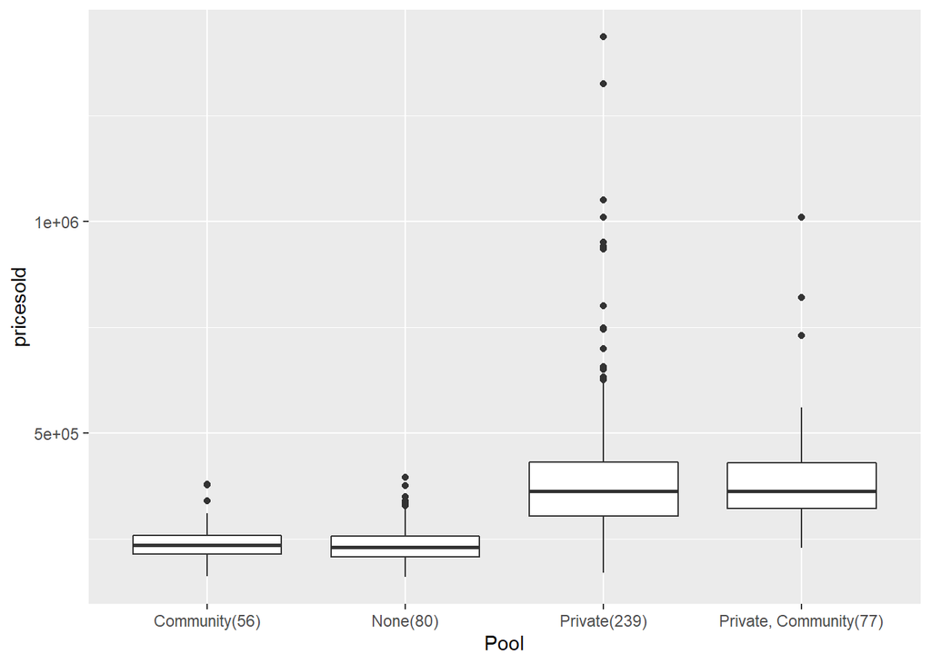

Does type of Roof matter?

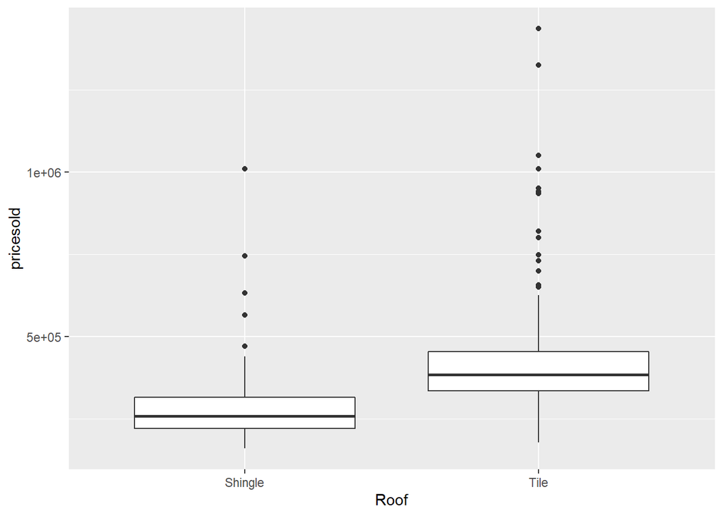

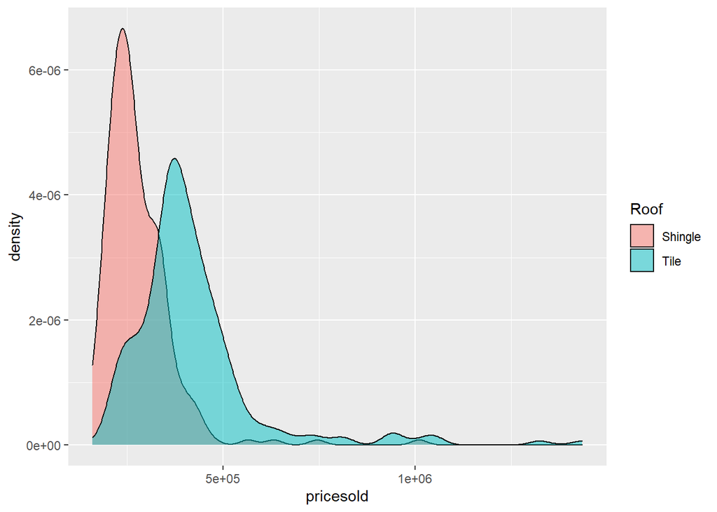

Do old houses go for cheap price?

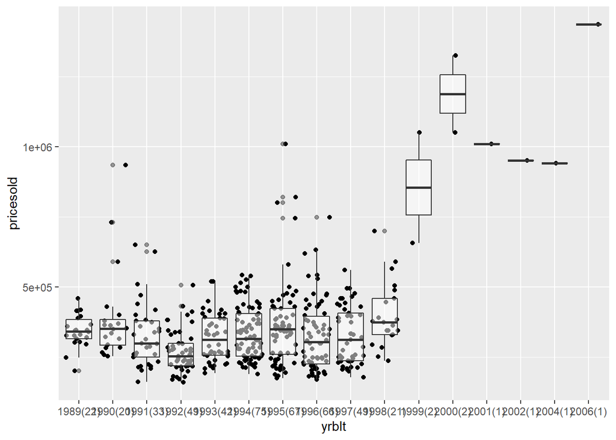

Spa’s increase the value of a house?

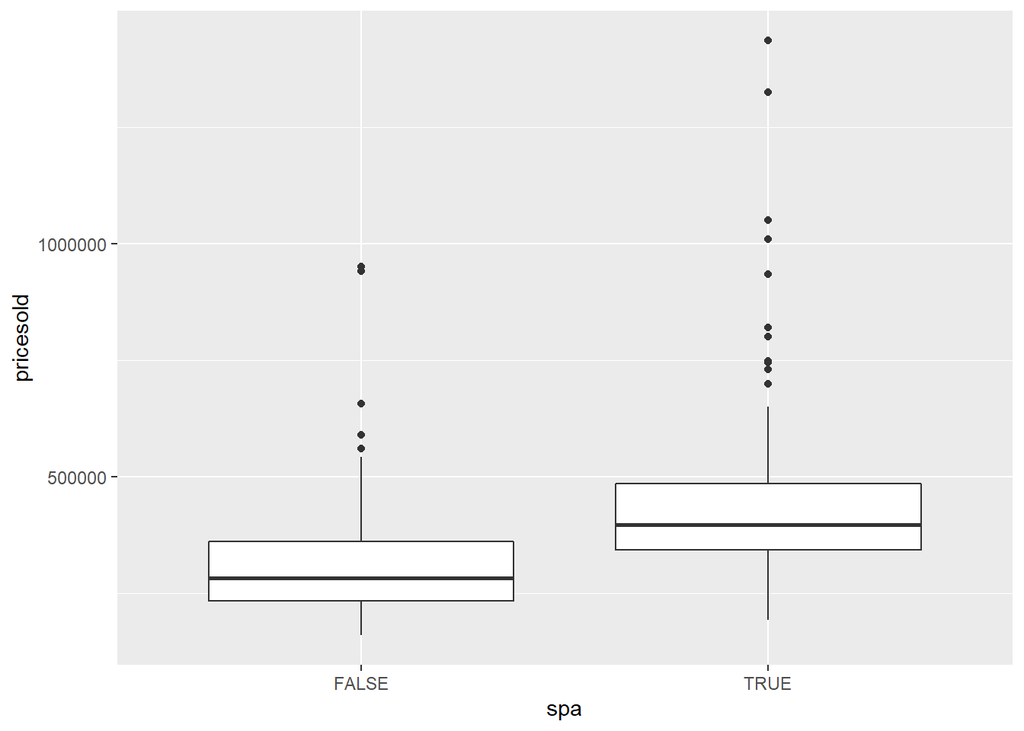

Does foreclosures affect selling price?

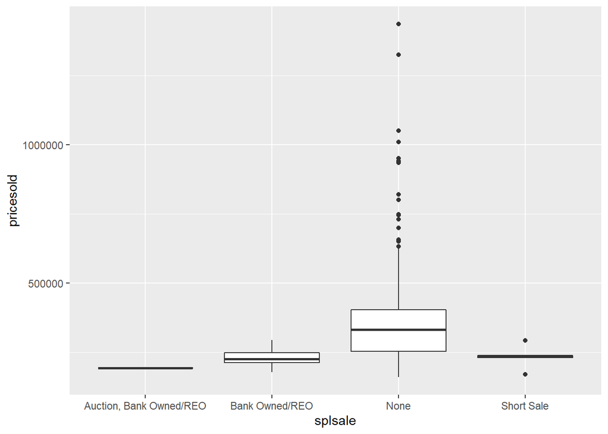

Having more beds increases house value?

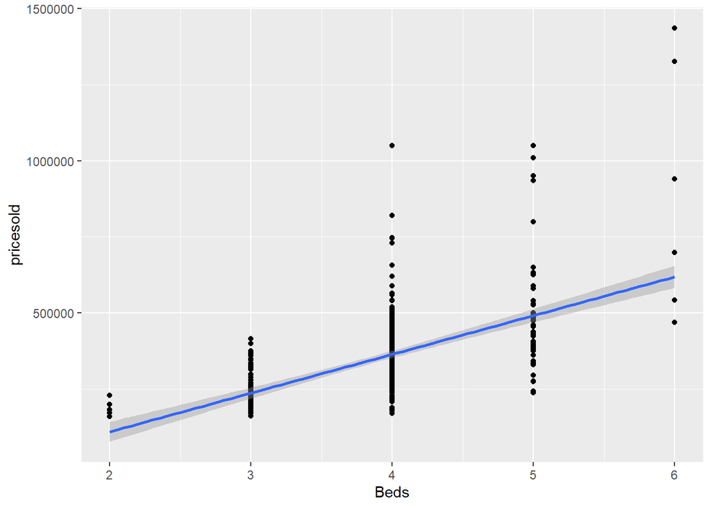

### Models

Exponential models predicting house value

```r
m1_sp <- lm(log(pricesold) ~ Beds + bath + garages + yrsold +  adom + Pool + spa + lotsqft + sqft + Roof, data = df)
summary(m1_sp)
```

```
##
## Call:
## lm(formula = log(pricesold) ~ Beds + bath + garages + yrsold +
##     adom + Pool + spa + lotsqft + sqft + Roof, data = df)
##
## Residuals:
##      Min       1Q   Median       3Q      Max
## -0.46214 -0.06326  0.00669  0.07705  0.40703
##
## Coefficients:
##                            Estimate   Std. Error t value             Pr(>|t|)
## (Intercept)            11.390499475  0.065672145 173.445 < 0.0000000000000002
## Beds                    0.019012695  0.011593389   1.640             0.101730
## bath                    0.039626086  0.016173320   2.450             0.014672
## garages                 0.041308243  0.013808406   2.992             0.002932
## yrsold                  0.009289011  0.001967840   4.720      0.0000031703901
## adom                   -0.000441389  0.000077795  -5.674      0.0000000254014
## PoolNone               -0.018154775  0.020554219  -0.883             0.377578
## PoolPrivate             0.071181495  0.019853628   3.585             0.000374
## PoolPrivate, Community  0.094094368  0.022619291   4.160      0.0000383109452
## spaTRUE                 0.050759152  0.013918052   3.647             0.000297
## lotsqft                 0.000011405  0.000001556   7.332      0.0000000000011
## sqft                    0.000224734  0.000016434  13.675 < 0.0000000000000002
## RoofTile                0.088816042  0.013008620   6.827      0.0000000000289
##
## (Intercept)            ***
## Beds
## bath                   *
## garages                **
## yrsold                 ***
## adom                   ***
## PoolNone
## PoolPrivate            ***
## PoolPrivate, Community ***
## spaTRUE                ***
## lotsqft                ***
## sqft                   ***
## RoofTile               ***
## ---
## Signif. codes:  0 '***' 0.001 '**' 0.01 '*' 0.05 '.' 0.1 ' ' 1
##
## Residual standard error: 0.1175 on 439 degrees of freedom
## Multiple R-squared:  0.8932, Adjusted R-squared:  0.8903
## F-statistic: 305.9 on 12 and 439 DF,  p-value: < 0.00000000000000022
```

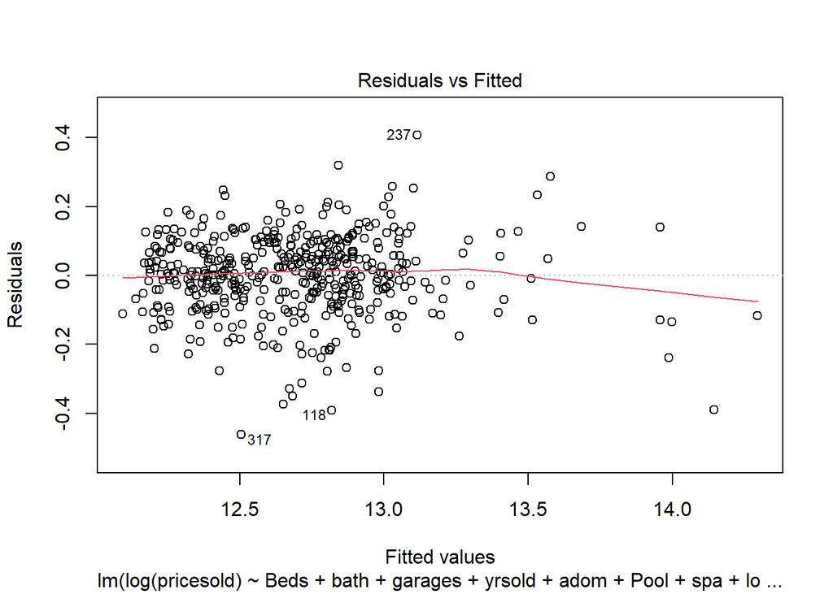

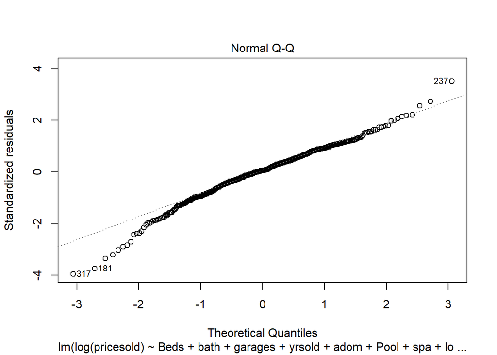

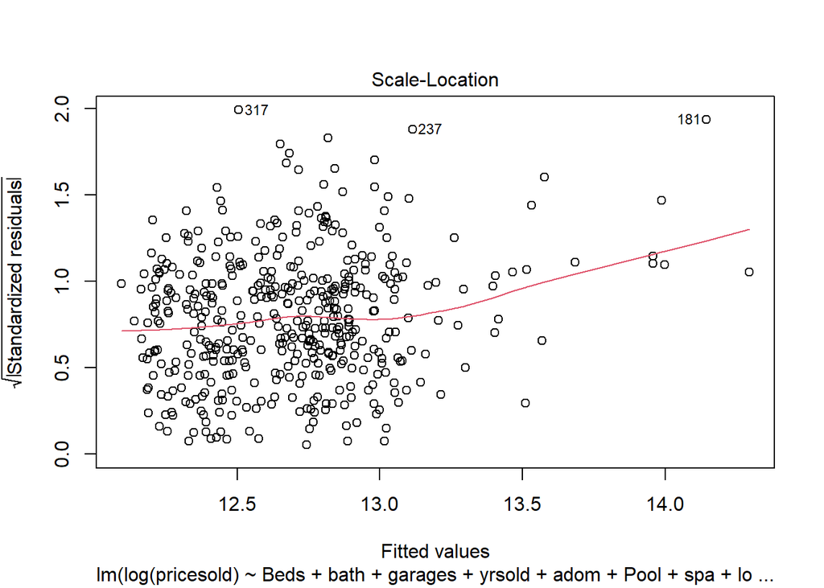

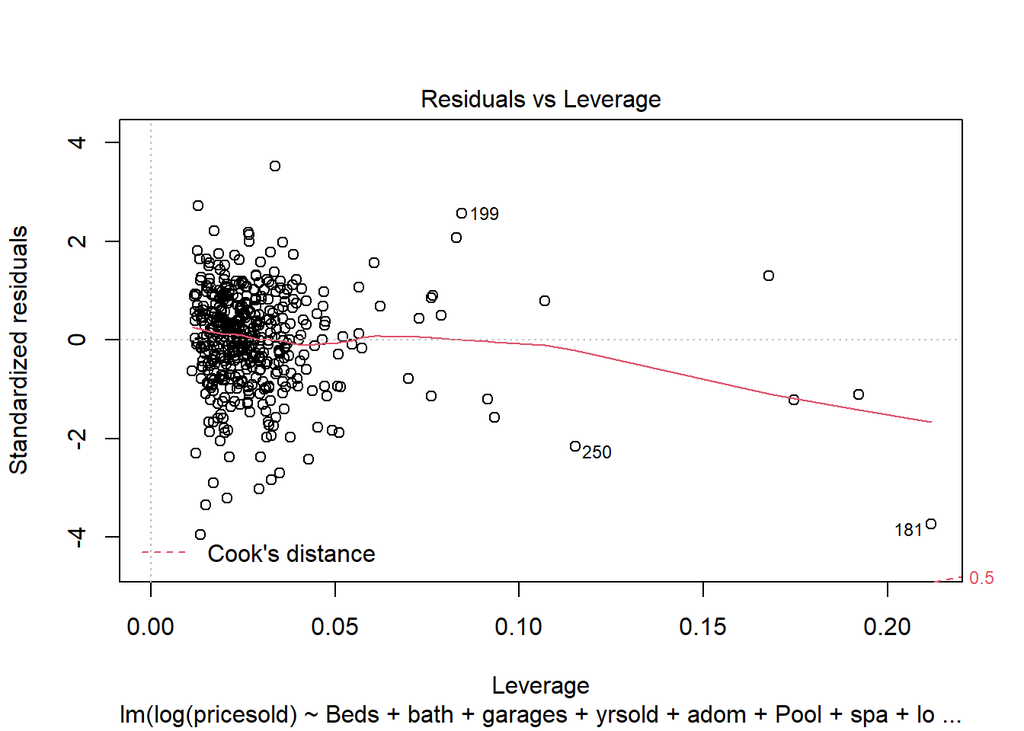

```r
plot(m1_sp)
```

Testing for OLS assumptions

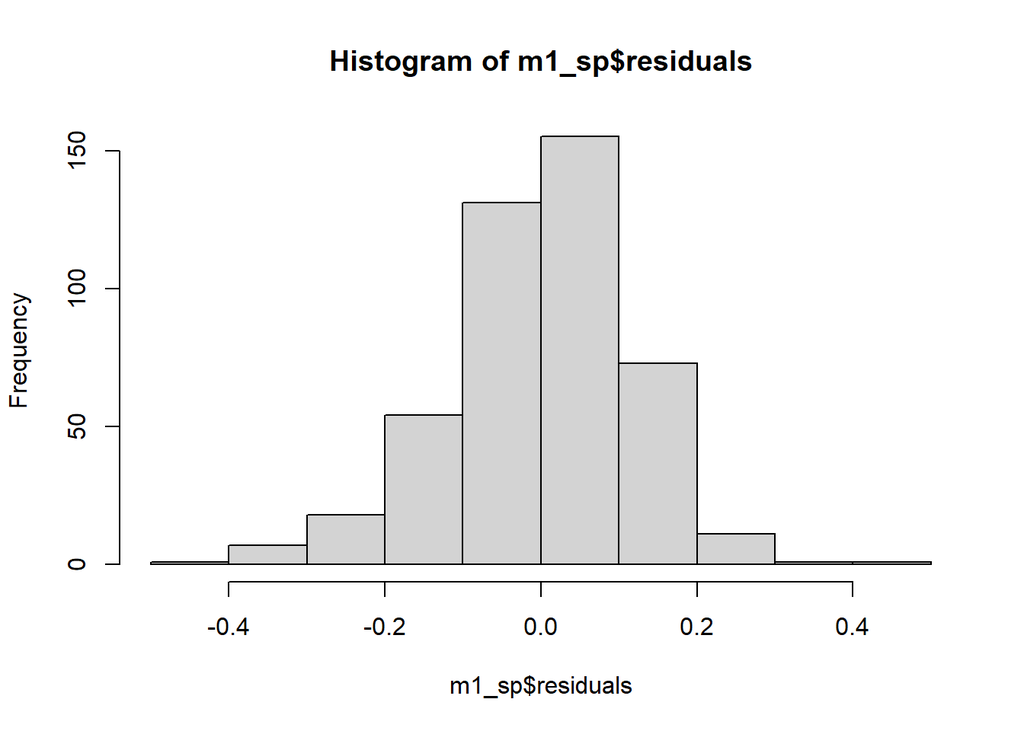

```r
hist(m1_sp$residuals)
```

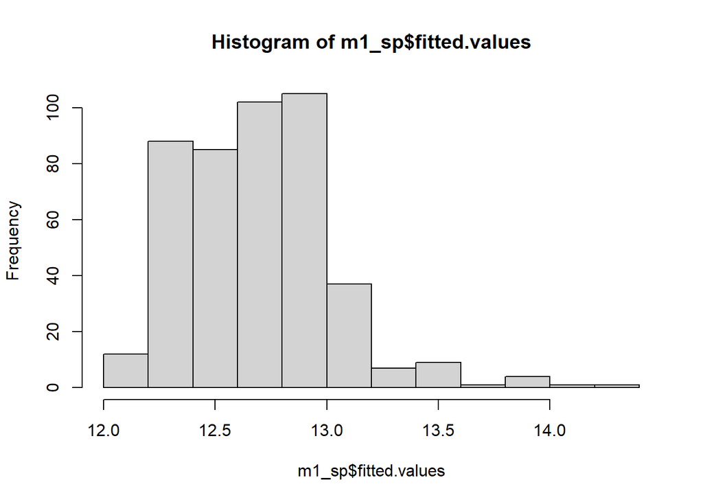

```r
hist(m1_sp$fitted.values)
```

```r
print("Normality - Shapiro Wilks test : ") # since sample less than 2000
```

```
## [1] "Normality - Shapiro Wilks test : "
```

```r
shapiro.test(m1_sp$residuals)
```

```
##
##  Shapiro-Wilk normality test
##
## data:  m1_sp$residuals
## W = 0.97965, p-value = 0.000005777
```

```r
print("Bartlett's test : ")
```

```
## [1] "Bartlett's test : "
```

```r
bartlett.test(list(m1_sp$residuals,m1_sp$fitted.values))
```

```
##
##  Bartlett test of homogeneity of variances
##
## data:  list(m1_sp$residuals, m1_sp$fitted.values)
## Bartlett's K-squared = 434.01, df = 1, p-value < 0.00000000000000022
```

```r
print("Durbin-Watson's test : ")
```

```
## [1] "Durbin-Watson's test : "
```

```r
lmtest::dwtest(m1_sp)
```

```
##
##  Durbin-Watson test
##
## data:  m1_sp
## DW = 2.0337, p-value = 0.6101
## alternative hypothesis: true autocorrelation is greater than 0
```

```r
#install.packages("car")
car::vif(m1_sp)
```

```
##             GVIF Df GVIF^(1/(2*Df))
## Beds    2.175100  1        1.474822
## bath    4.368095  1        2.089999
## garages 1.945585  1        1.394842
## yrsold  1.145028  1        1.070060
## adom    1.293718  1        1.137417
## Pool    1.587379  3        1.080057
## spa     1.286954  1        1.134440
## lotsqft 3.014926  1        1.736354
## sqft    5.948183  1        2.438890
## Roof    1.384592  1        1.176687
```

```r
m2_sp <- lm(log(pricesold) ~ Beds + bath + garages + yrsold + adom + Pool + spa + lppersqft + Roof, data = df)
summary(m2_sp)
```

```
##
## Call:
## lm(formula = log(pricesold) ~ Beds + bath + garages + yrsold +
##     adom + Pool + spa + lppersqft + Roof, data = df)
##
## Residuals:
##      Min       1Q   Median       3Q      Max
## -0.32778 -0.08031 -0.00853  0.07772  0.40654
##
## Coefficients:
##                           Estimate  Std. Error t value             Pr(>|t|)
## (Intercept)            10.56657615  0.07465985 141.530 < 0.0000000000000002 ***
## Beds                    0.08773725  0.01170414   7.496    0.000000000000365 ***
## bath                    0.18630100  0.01363844  13.660 < 0.0000000000000002 ***
## garages                 0.05996755  0.01423624   4.212    0.000030675609611 ***
## yrsold                  0.00922630  0.00204530   4.511    0.000008289690943 ***
## adom                    0.00024099  0.00007701   3.129             0.001868 **
## PoolNone               -0.01423036  0.02147024  -0.663             0.507809
## PoolPrivate             0.09375760  0.02067708   4.534    0.000007458523987 ***
## PoolPrivate, Community  0.09207842  0.02362358   3.898             0.000112 ***
## spaTRUE                 0.03239842  0.01466989   2.208             0.027724 *
## lppersqft               0.00585526  0.00031792  18.417 < 0.0000000000000002 ***
## RoofTile                0.06357728  0.01370856   4.638    0.000004650602585 ***
## ---
## Signif. codes:  0 '***' 0.001 '**' 0.01 '*' 0.05 '.' 0.1 ' ' 1
##
## Residual standard error: 0.1227 on 440 degrees of freedom
## Multiple R-squared:  0.8833, Adjusted R-squared:  0.8804
## F-statistic: 302.7 on 11 and 440 DF,  p-value: < 0.00000000000000022
```

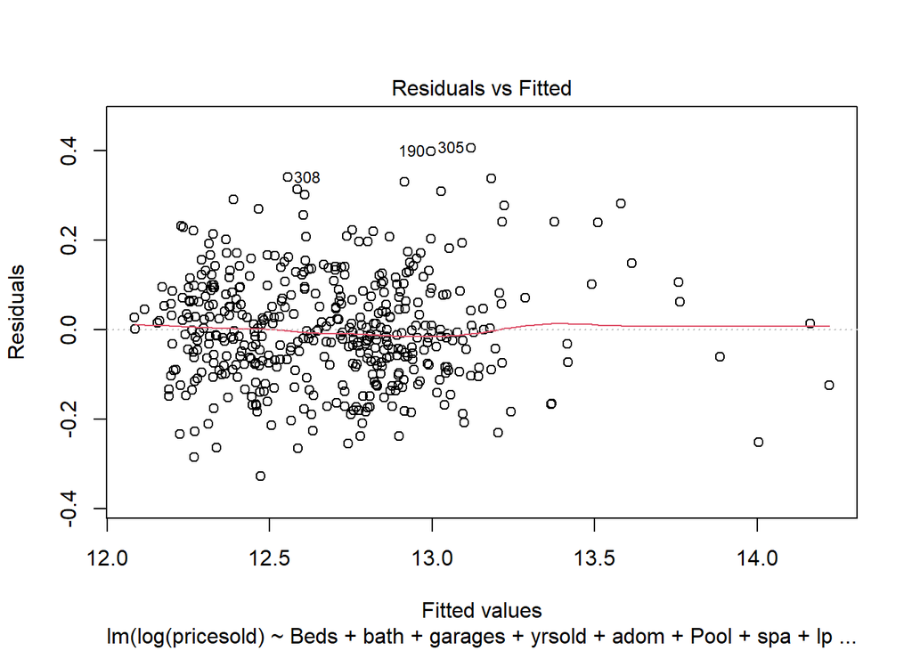

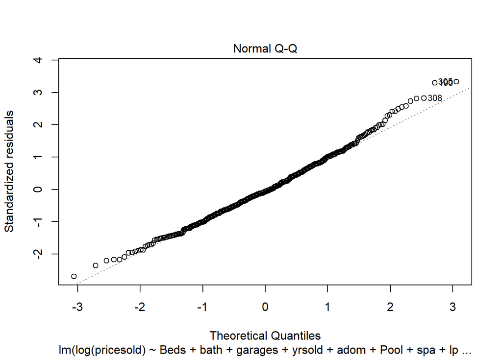

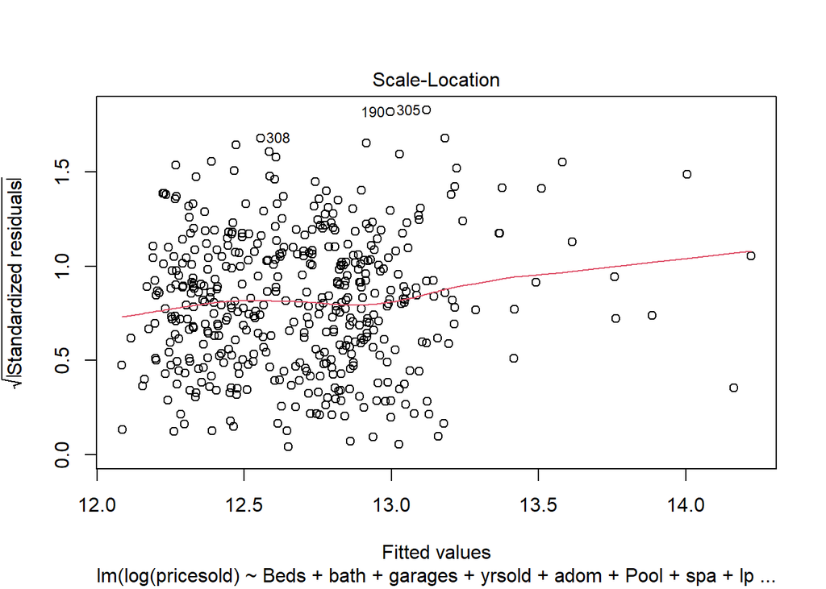

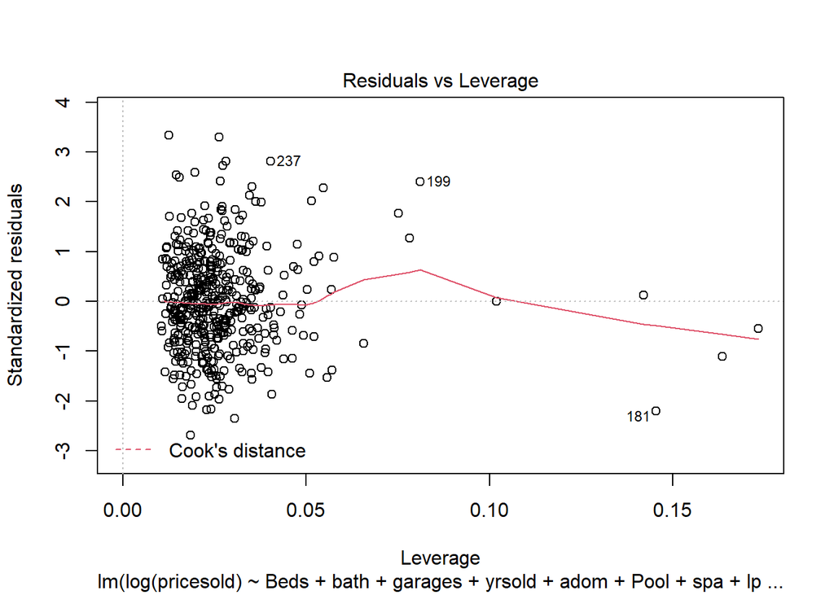

```r
plot(m2_sp)
```

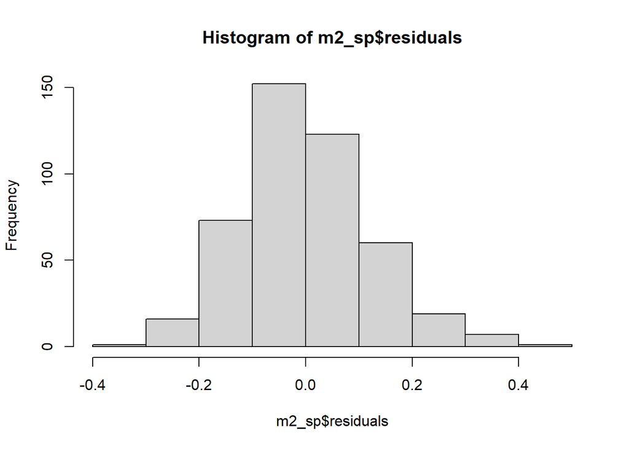

```r
hist(m2_sp$residuals)
```

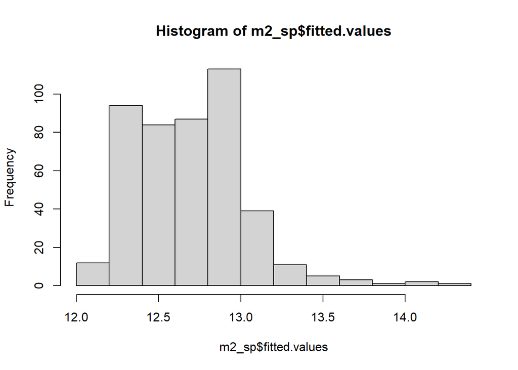

```r
hist(m2_sp$fitted.values)
```

```r
print("Normality - Shapiro Wilks test : ") # since sample less than 2000
```

```
## [1] "Normality - Shapiro Wilks test : "
```

```r
shapiro.test(m2_sp$residuals)
```

```
##
##  Shapiro-Wilk normality test
##
## data:  m2_sp$residuals
## W = 0.9919, p-value = 0.01459
```

```r
print("Bartlett's test : ")
```

```
## [1] "Bartlett's test : "
```

```r
bartlett.test(list(m2_sp$residuals,m2_sp$fitted.values))
```

```
##
##  Bartlett test of homogeneity of variances
##
## data:  list(m2_sp$residuals, m2_sp$fitted.values)
## Bartlett's K-squared = 399.03, df = 1, p-value < 0.00000000000000022
```

```r
print("Durbin-Watson's test : ")
```

```
## [1] "Durbin-Watson's test : "
```

```r
lmtest::dwtest(m2_sp)
```

```
##
##  Durbin-Watson test
##
## data:  m2_sp
## DW = 1.7628, p-value = 0.004628
## alternative hypothesis: true autocorrelation is greater than 0
```

```r
car::vif(m2_sp)
```

```
##               GVIF Df GVIF^(1/(2*Df))
## Beds      2.033039  1        1.425847
## bath      2.848602  1        1.687780
## garages   1.896540  1        1.377149
## yrsold    1.134381  1        1.065073
## adom      1.162466  1        1.078177
## Pool      1.580076  3        1.079227
## spa       1.311197  1        1.145075
## lppersqft 1.456100  1        1.206689
## Roof      1.410104  1        1.187478
```

```r
#create years old field
```

```r
m3_sp <- lm(log(pricesold) ~ Beds + bath + garages + Pool + spa + lppersqft + Roof, data = df)
summary(m3_sp)
```

```
##
## Call:
## lm(formula = log(pricesold) ~ Beds + bath + garages + Pool +
##     spa + lppersqft + Roof, data = df)
##
## Residuals:
##      Min       1Q   Median       3Q      Max
## -0.35184 -0.08697 -0.00894  0.07633  0.40040
##
## Coefficients:
##                          Estimate Std. Error t value             Pr(>|t|)
## (Intercept)            10.8129565  0.0534062 202.466 < 0.0000000000000002 ***
## Beds                    0.0838112  0.0119920   6.989      0.0000000000103 ***
## bath                    0.1910123  0.0136035  14.041 < 0.0000000000000002 ***
## garages                 0.0502035  0.0144534   3.473             0.000564 ***
## PoolNone               -0.0090622  0.0220262  -0.411             0.680959
## PoolPrivate             0.1052007  0.0210170   5.006      0.0000008060784 ***
## PoolPrivate, Community  0.1021286  0.0240287   4.250      0.0000260610709 ***
## spaTRUE                 0.0368675  0.0150346   2.452             0.014585 *
## lppersqft               0.0058208  0.0003232  18.009 < 0.0000000000000002 ***
## RoofTile                0.0629284  0.0140636   4.475      0.0000097520014 ***
## ---
## Signif. codes:  0 '***' 0.001 '**' 0.01 '*' 0.05 '.' 0.1 ' ' 1
##
## Residual standard error: 0.126 on 442 degrees of freedom
## Multiple R-squared:  0.8763, Adjusted R-squared:  0.8738
## F-statistic:   348 on 9 and 442 DF,  p-value: < 0.00000000000000022
```

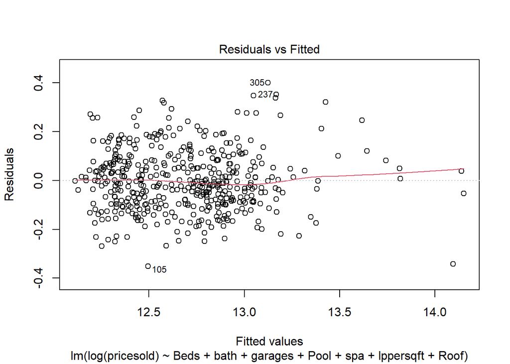

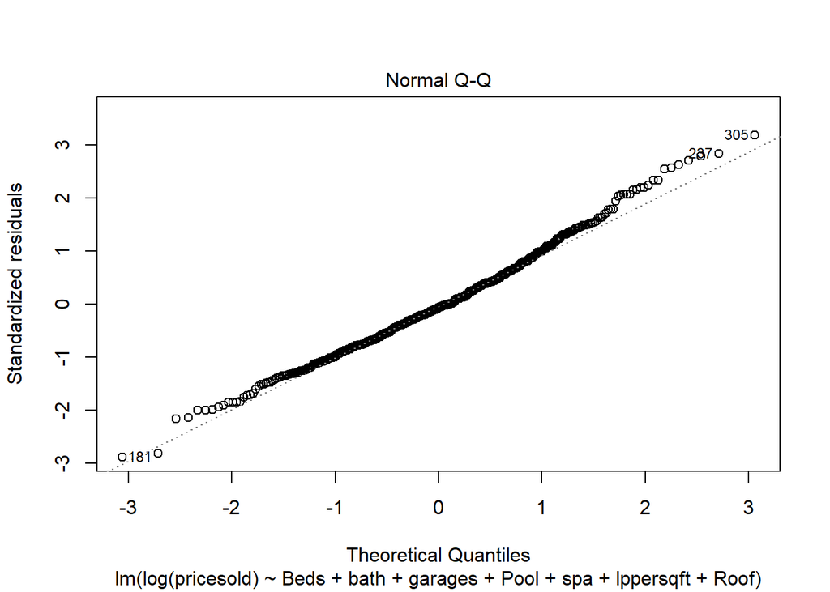

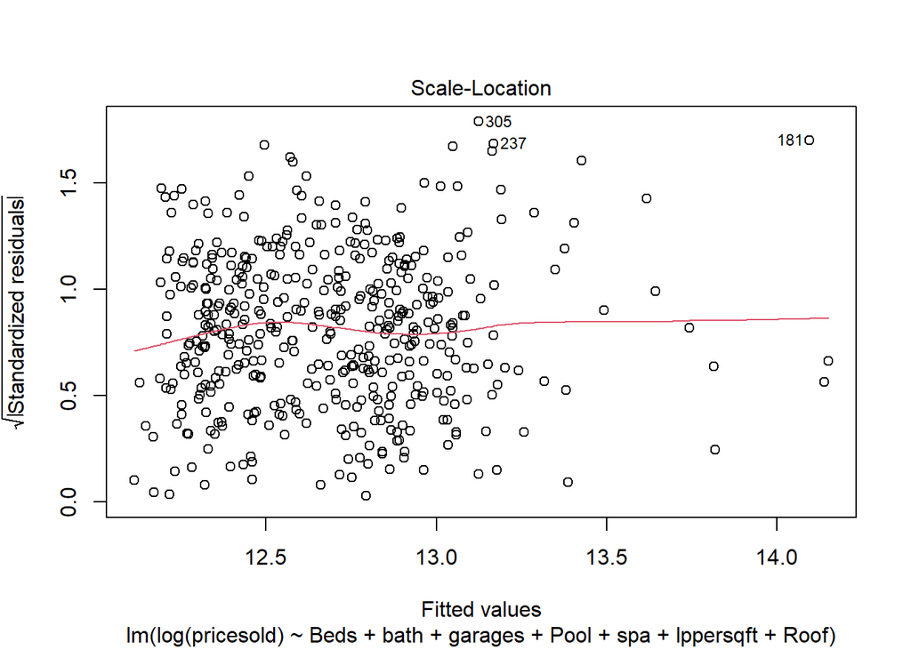

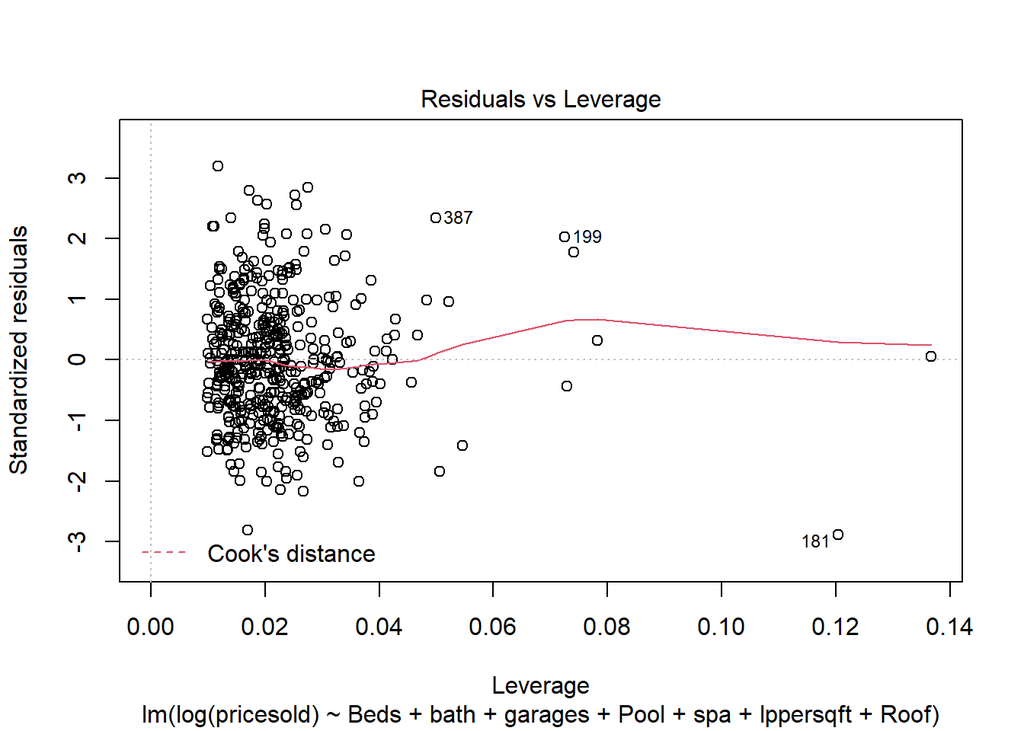

```r
plot(m3_sp)
```

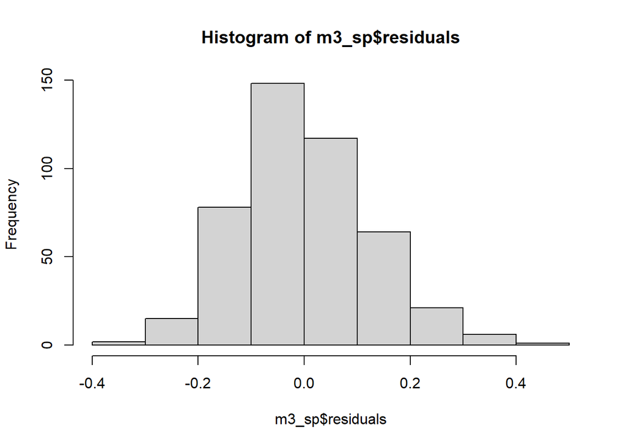

```r
hist(m3_sp$residuals)
```

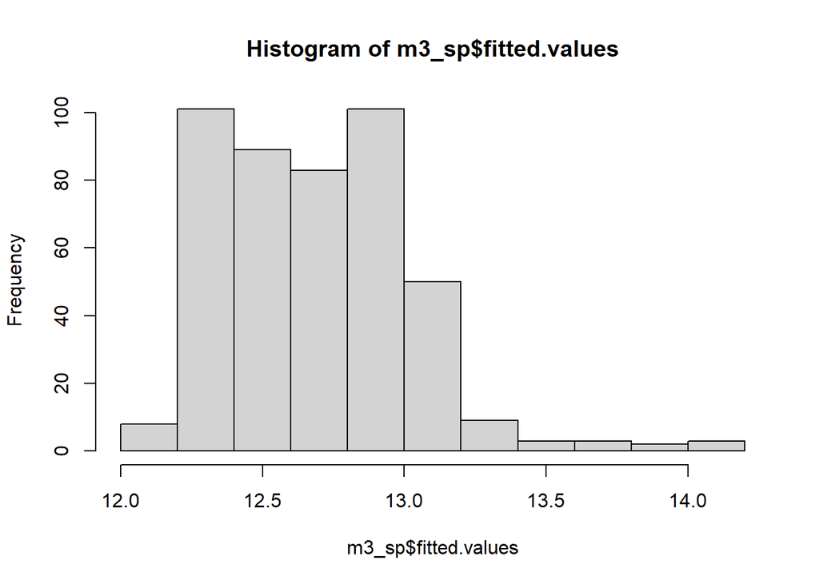

```r
hist(m3_sp$fitted.values)
```

```r
print("Normality - Shapiro Wilks test : ") # since sample less than 2000
```

```
## [1] "Normality - Shapiro Wilks test : "
```

```r
shapiro.test(m3_sp$residuals)
```

```
##
##  Shapiro-Wilk normality test
##
## data:  m3_sp$residuals
## W = 0.991, p-value = 0.007457
```

```r
print("Bartlett's test : ")
```

```
## [1] "Bartlett's test : "
```

```r
bartlett.test(list(m3_sp$residuals,m3_sp$fitted.values))
```

```
##
##  Bartlett test of homogeneity of variances
##
## data:  list(m3_sp$residuals, m3_sp$fitted.values)
## Bartlett's K-squared = 376.52, df = 1, p-value < 0.00000000000000022
```

```r
print("Durbin-Watson's test : ")
```

```
## [1] "Durbin-Watson's test : "
```

```r
lmtest::dwtest(m3_sp)
```

```
##
##  Durbin-Watson test
##
## data:  m3_sp
## DW = 1.6416, p-value = 0.0000537
## alternative hypothesis: true autocorrelation is greater than 0
```

```r
car::vif(m3_sp)
```

```
##               GVIF Df GVIF^(1/(2*Df))
## Beds      2.023422  1        1.422470
## bath      2.686839  1        1.639158
## garages   1.853298  1        1.361359
## Pool      1.529400  3        1.073380
## spa       1.305670  1        1.142659
## lppersqft 1.426913  1        1.194535
## Roof      1.407008  1        1.186174
```

Comparing the three models to check our estimates are consistent.

```r
stargazer::stargazer(m1_sp,m2_sp,m3_sp, title="Results", type = "text")
```

```
##
## Results
## ===================================================================================================
##                                                    Dependent variable:
##                        ----------------------------------------------------------------------------
##                                                       log(pricesold)
##                                   (1)                       (2)                      (3)
## ---------------------------------------------------------------------------------------------------
## Beds                             0.019                   0.088***                  0.084***
##                                 (0.012)                   (0.012)                  (0.012)
##
## bath                            0.040**                  0.186***                  0.191***
##                                 (0.016)                   (0.014)                  (0.014)
##
## garages                        0.041***                  0.060***                  0.050***
##                                 (0.014)                   (0.014)                  (0.014)
##
## yrsold                         0.009***                  0.009***
##                                 (0.002)                   (0.002)
##
## adom                          -0.0004***                 0.0002***
##                                (0.0001)                  (0.0001)
##
## PoolNone                        -0.018                    -0.014                    -0.009
##                                 (0.021)                   (0.021)                  (0.022)
##
## PoolPrivate                    0.071***                  0.094***                  0.105***
##                                 (0.020)                   (0.021)                  (0.021)
##
## PoolPrivate, Community         0.094***                  0.092***                  0.102***
##                                 (0.023)                   (0.024)                  (0.024)
##
## spa                            0.051***                   0.032**                  0.037**
##                                 (0.014)                   (0.015)                  (0.015)
##
## lotsqft                       0.00001***
##                                (0.00000)
##
## sqft                           0.0002***
##                                (0.00002)
##
## lppersqft                                                0.006***                  0.006***
##                                                          (0.0003)                  (0.0003)
##
## RoofTile                       0.089***                  0.064***                  0.063***
##                                 (0.013)                   (0.014)                  (0.014)
##
## Constant                       11.390***                 10.567***                10.813***
##                                 (0.066)                   (0.075)                  (0.053)
##
## ---------------------------------------------------------------------------------------------------
## Observations                      452                       452                      452
## R2                               0.893                     0.883                    0.876
## Adjusted R2                      0.890                     0.880                    0.874
## Residual Std. Error        0.118 (df = 439)          0.123 (df = 440)          0.126 (df = 442)
## F Statistic            305.941*** (df = 12; 439) 302.680*** (df = 11; 440) 347.965*** (df = 9; 442)
## ===================================================================================================
## Note:                                                                   *p<0.1; **p<0.05; ***p<0.01
```

[output not shown]